# Diamonds

Metin Yüksel GÜNGÖR

9/11/2020

# General Informations

Diamond is a solid form of the element carbon with its atoms arranged in a crystal structure called diamond cubic. Diamond, the most famed and fabled of all gemstones, is very unique in many ways. Renowned for being the hardest substance on earth, its sparkling fire, durability, and rarity make Diamond the most prized of all gems.

There are five main factors that should be kept in mind while comparing the prices of diamonds. These include Shape, Cut, Color, Clarity, and Carat. Excellence of each of these factors makes the difference in the price of a diamond.

**1) Shape**

There are many shapes of diamonds available in the marketplace. Most common shapes are round, princess, oval, asscher, emerald, radiant, cushion, marquise, and pear. Selecting the shape of a diamond depends on your preference, but it would be the first step in comparing the prices of diamonds.

[Click here for more information.](https://www.petragems.com/education/diamond-shapes/)

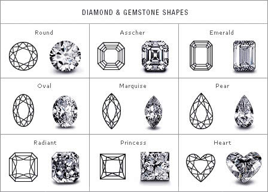

Types of Shapes

**2) Cut**

In generally, the second important factor in determining the price a diamond is the Cut of a diamond. The brilliance of a diamond highly depends on its cut. Here is an outline that will assist you in understanding the The Gemological Institute of America (GIA)’s cut grading system and what differentiates an excellent from a good or fair cut.

**Excellent**: This category has high scintillation, brilliance and an even pattern of dark and light areas.

**Very good**: While this grade has high scintillation and brilliance, they are darker n the edges or the centre. Sometimes, a diamond can have a higher scintillation and brilliance, but the grade lowered by its pattern.

**Good**: This category is a bit dark and has lower scintillation. A diamond can be downgraded by its weight ratio or pattern.

**Fair**: A gem in this grade has little scintillation and brilliance.

**Poor**: Gems in this grade have extremely poor proportions and display little scintillation or brilliance.

[Click here for more information.](https://www.petragems.com/education/diamond-cut/)

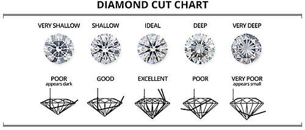

Cut Grading System

**3) Carat**

The third important factor is the Carat Weight of a diamond. Carat is the weighing scale for any diamond and the greater the weight, the expensive it is. Diamonds that weigh below a full carat are generally less expensive than ones that are above a full carat.

[Click here for more information.](https://www.petragems.com/education/diamond-carat-weight/)

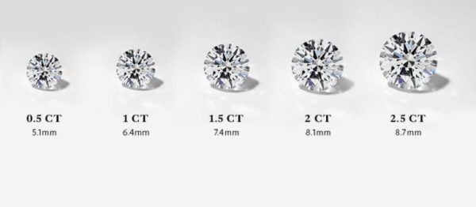

Carat Weight Chart

**4) Color**

[Click here for more information.](https://www.petragems.com/education/diamond-color/)

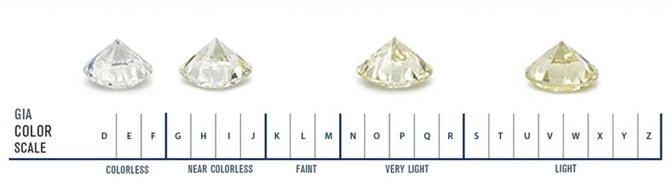

Color Scale

**5) Clarity**

The fifth factor in determining the price of a diamond is the Clarity of a diamond. Eye-clean clarity means that the inclusions are not noticeable with an unaided eye. Clarity grading determines the amount of inclusions within a diamond. Clarity is assessed based off The Gemological Institute of America (GIA)’s grading scale that ranges from Flawless or FL to included 3 or I3.

[Click here for more information.](https://www.petragems.com/education/diamond-clarity/)

[figure not shown]

Clarity Scale

# Activation of Packages

```r
library(tidyverse)
```

```r
library(ggplot2)
library(corrplot)
library(rpart)
library(rpart.plot)
library(caret)
```

# Overview of Data

```r
glimpse(diamonds)
```

```
## Rows: 53,940
## Columns: 10
## $ carat   <dbl> 0.23, 0.21, 0.23, 0.29, 0.31, 0.24, 0.24, 0.26, 0.22, 0.23,...
## $ cut     <ord> Ideal, Premium, Good, Premium, Good, Very Good, Very Good, ...
## $ color   <ord> E, E, E, I, J, J, I, H, E, H, J, J, F, J, E, E, I, J, J, J,...
## $ clarity <ord> SI2, SI1, VS1, VS2, SI2, VVS2, VVS1, SI1, VS2, VS1, SI1, VS...
## $ depth   <dbl> 61.5, 59.8, 56.9, 62.4, 63.3, 62.8, 62.3, 61.9, 65.1, 59.4,...
## $ table   <dbl> 55, 61, 65, 58, 58, 57, 57, 55, 61, 61, 55, 56, 61, 54, 62,...
## $ price   <int> 326, 326, 327, 334, 335, 336, 336, 337, 337, 338, 339, 340,...
## $ x       <dbl> 3.95, 3.89, 4.05, 4.20, 4.34, 3.94, 3.95, 4.07, 3.87, 4.00,...
## $ y       <dbl> 3.98, 3.84, 4.07, 4.23, 4.35, 3.96, 3.98, 4.11, 3.78, 4.05,...
## $ z       <dbl> 2.43, 2.31, 2.31, 2.63, 2.75, 2.48, 2.47, 2.53, 2.49, 2.39,...
```

```r
summary(diamonds)
```

```
##      carat               cut        color        clarity          depth
##  Min.   :0.2000   Fair     : 1610   D: 6775   SI1    :13065   Min.   :43.00
##  1st Qu.:0.4000   Good     : 4906   E: 9797   VS2    :12258   1st Qu.:61.00
##  Median :0.7000   Very Good:12082   F: 9542   SI2    : 9194   Median :61.80
##  Mean   :0.7979   Premium  :13791   G:11292   VS1    : 8171   Mean   :61.75
##  3rd Qu.:1.0400   Ideal    :21551   H: 8304   VVS2   : 5066   3rd Qu.:62.50
##  Max.   :5.0100                     I: 5422   VVS1   : 3655   Max.   :79.00
##                                     J: 2808   (Other): 2531
##      table           price             x                y
##  Min.   :43.00   Min.   :  326   Min.   : 0.000   Min.   : 0.000
##  1st Qu.:56.00   1st Qu.:  950   1st Qu.: 4.710   1st Qu.: 4.720
##  Median :57.00   Median : 2401   Median : 5.700   Median : 5.710
##  Mean   :57.46   Mean   : 3933   Mean   : 5.731   Mean   : 5.735
##  3rd Qu.:59.00   3rd Qu.: 5324   3rd Qu.: 6.540   3rd Qu.: 6.540
##  Max.   :95.00   Max.   :18823   Max.   :10.740   Max.   :58.900
##
##        z
##  Min.   : 0.000
##  1st Qu.: 2.910
##  Median : 3.530
##  Mean   : 3.539
##  3rd Qu.: 4.040
##  Max.   :31.800
##
```

The data set has 53,940 observations and 10 variables. These variables are;

**Carat**: weight of the diamond (between 0.2 and 5.01)

**Cut**: quality of the cut (fair, good, very good, premium, ideal) worst to best

**Clarity**: clarity of the diamond (SI1, VS2, SI2, VS1, VVS2, VVS1, other)

**Depth**: total depth percentage ( z / ((x+y)/2) ) (between 43 and 79)

**Table**: diamond crown width relative to diamond’s widest point (between 43 and 95)

**Price**: price in US dollars (between 326 and 18823)

**X**: length of the diamond in mm (between 0 and 10.74)

**Y**: width of the diamond in mm (between 0 and 58.9)

**Z**: depth of the diamond in mm (between 0 and 31.8)

# Exploration of Data

As i mentioned in general information, our data has four main factors(except shape) that should be kept in mind while comparing the prices of diamonds. So, let’s make clear the characteristics of this four variables of the data and what is in the dataset.

## Carat

In this data set, the carat states the weight of the diamond. In this below table, the most preferred carats are shown.

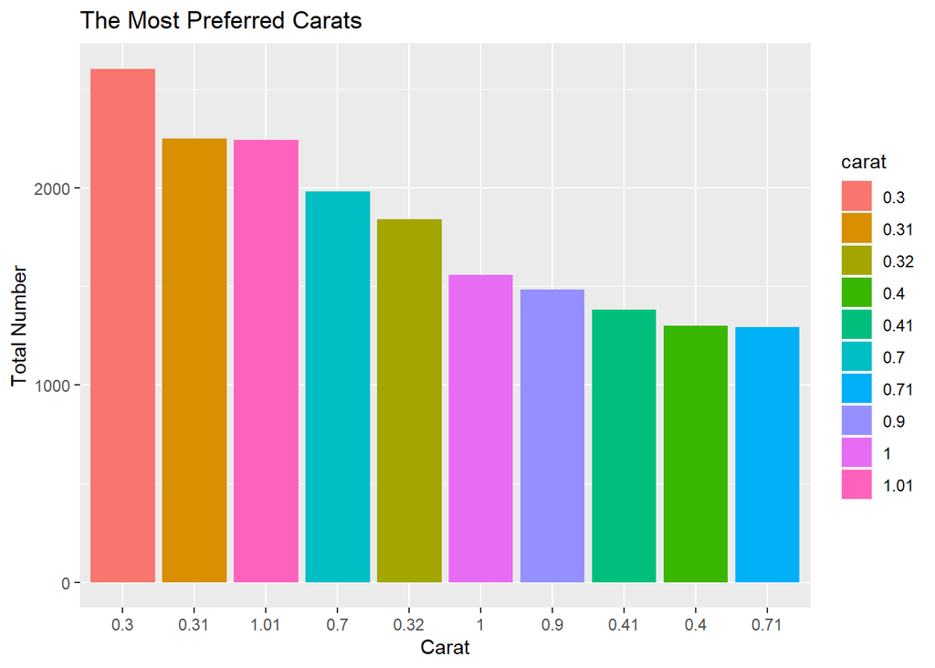

```r
diamonds %>%
  mutate(carat = factor(carat)) %>%
  group_by(carat) %>%
  summarise(caratnumber = n()) %>%
  arrange(desc(caratnumber)) %>%
  head(10) %>%
  ggplot(., aes(y=caratnumber, x = reorder(carat, -caratnumber), fill = carat)) +
  geom_col()+
  labs(title = "The Most Preferred Carats",
       x = "Carat",
       y = "Total Number")
```

According to the plot, the most preferred carat is 0.3 and the 10th carat is 0.71.

And in the below table; total numbers, min prices, average prices, and max prices are shown of diamonds ordered by carats.

```r
diamonds %>%
  group_by(carat) %>%
  summarise(TotalNumber = n(),
            MinPrice = min(price),
            AveragePrice = mean(price),
            MaxPrice = max(price))
```

```
## # A tibble: 273 x 5
##    carat TotalNumber MinPrice AveragePrice MaxPrice
##    <dbl>       <int>    <int>        <dbl>    <int>
##  1 0.2            12      345         365.      367
##  2 0.21            9      326         380.      394
##  3 0.22            5      337         391.      470
##  4 0.23          293      326         486.      688
##  5 0.24          254      336         505.      963
##  6 0.25          212      357         551.     1186
##  7 0.26          253      337         551.      814
##  8 0.27          233      361         575.      893
##  9 0.28          198      360         580.      828
## 10 0.290         130      334         601.     1776
## # ... with 263 more rows
```

## Cut

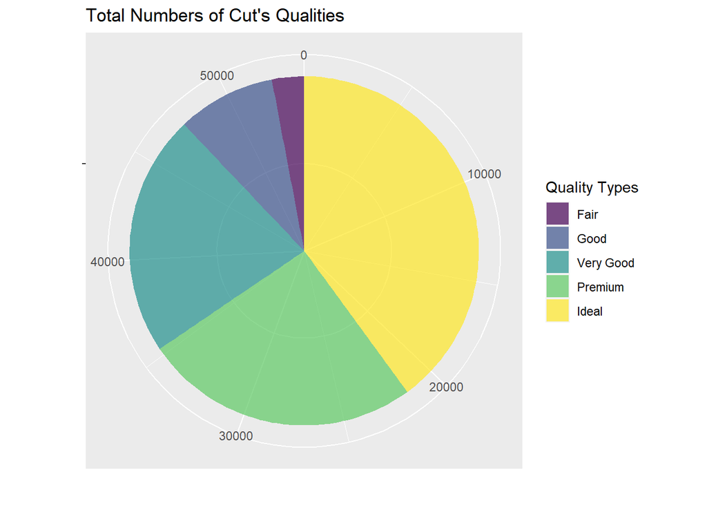

```r
diamonds %>%
  group_by(cut) %>%
  summarise(Totalnumber = n()) %>%
  ggplot(., aes(x = '', y = Totalnumber, fill = cut)) +
    geom_bar(stat = "identity", width = 1, alpha = 0.7) +
    coord_polar("y")+
   labs(title = "Total Numbers of Cut's Qualities ",
        x = "",
        y = "",
        fill = "Quality Types")
```

When we look at the below table, we can see that Fair and Premium cut quality types have highest average prices. According to this, We can understand that Cut is not the most important factor at setting the price. Also, the max and min prices of each type are pretty close.

```r
diamonds %>%
  group_by(cut) %>%
  summarise(TotalNumber = n(),
            MinPrice = min(price),
            AveragePrice = mean(price),
            MaxPrice = max(price))
```

```
## # A tibble: 5 x 5
##   cut       TotalNumber MinPrice AveragePrice MaxPrice
##   <ord>           <int>    <int>        <dbl>    <int>
## 1 Fair             1610      337        4359.    18574
## 2 Good             4906      327        3929.    18788
## 3 Very Good       12082      336        3982.    18818
## 4 Premium         13791      326        4584.    18823
## 5 Ideal           21551      326        3458.    18806
```

## Color

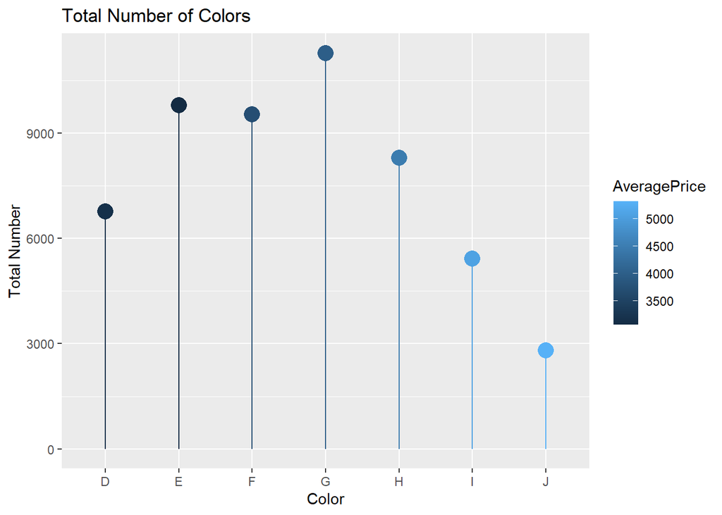

```r
diamonds %>%
  group_by(color) %>%
  summarise(colornumber = n(),
            AveragePrice = mean(price)) %>%
  ggplot(.,aes(x = color, y = colornumber, color = AveragePrice)) +
  geom_point(size=5) +
    geom_segment(aes(x=color,
                     xend=color,
                     y=0,
                     yend=colornumber))+
  labs(title = "Total Number of Colors",
       x = "Color",
       y = "Total Number")
```

```r
diamonds %>%
  group_by(color) %>%
  summarise(TotalNumber = n(),
            MinPrice = min(price),
            AveragePrice = mean(price),
            MaxPrice = max(price))
```

```
## # A tibble: 7 x 5
##   color TotalNumber MinPrice AveragePrice MaxPrice
##   <ord>       <int>    <int>        <dbl>    <int>
## 1 D            6775      357        3170.    18693
## 2 E            9797      326        3077.    18731
## 3 F            9542      342        3725.    18791
## 4 G           11292      354        3999.    18818
## 5 H            8304      337        4487.    18803
## 6 I            5422      334        5092.    18823
## 7 J            2808      335        5324.    18710
```

## Clarity

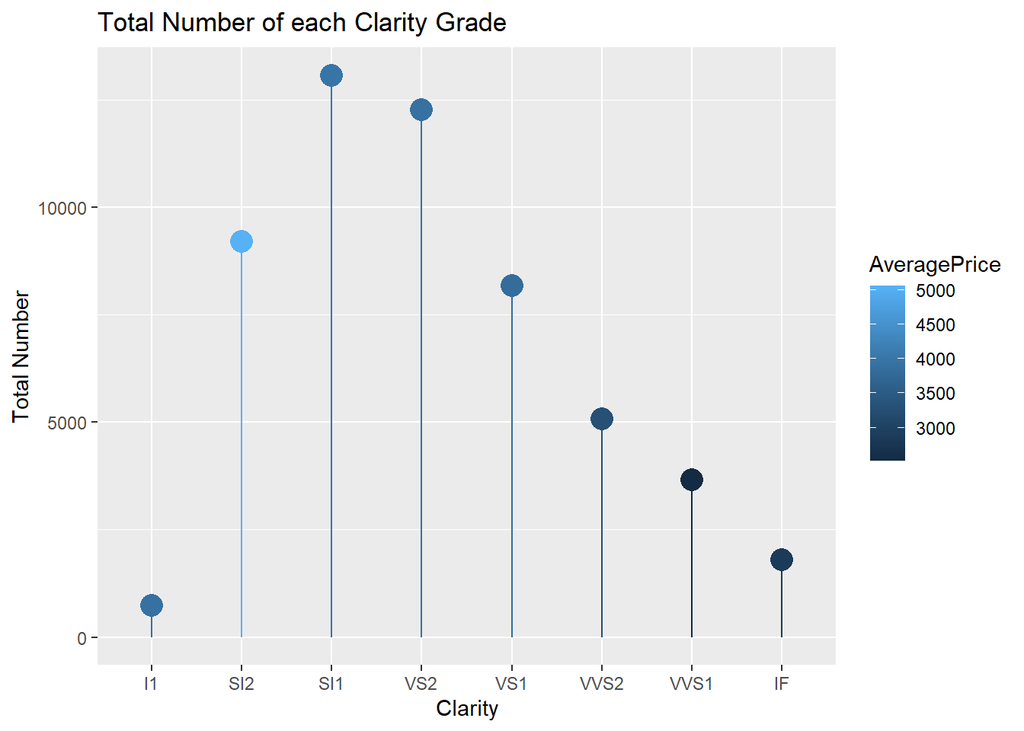

```r
diamonds %>%
  group_by(clarity) %>%
  summarise(claritynumber = n(),
            AveragePrice = mean(price)) %>%
  ggplot(.,aes(x = clarity, y = claritynumber, color = AveragePrice)) +
  geom_point(size=5) +
    geom_segment(aes(x=clarity,
                     xend=clarity,
                     y=0,
                     yend=claritynumber))+
  labs(title = "Total Number of each Clarity Grade",
       x = "Clarity",
       y = "Total Number")
```

When we look at the below table, we can see that SI2 clarity grade has the highest average price, then SI1, VS2, and I1 are nearly equal. Also, the max and min prices of each clarity grades are pretty close.

```r
diamonds %>%
  group_by(clarity) %>%
  summarise(TotalNumber = n(),
            MinPrice = min(price),
            AveragePrice = mean(price),
            MaxPrice = max(price))
```

```
## # A tibble: 8 x 5
##   clarity TotalNumber MinPrice AveragePrice MaxPrice
##   <ord>         <int>    <int>        <dbl>    <int>
## 1 I1              741      345        3924.    18531
## 2 SI2            9194      326        5063.    18804
## 3 SI1           13065      326        3996.    18818
## 4 VS2           12258      334        3925.    18823
## 5 VS1            8171      327        3839.    18795
## 6 VVS2           5066      336        3284.    18768
## 7 VVS1           3655      336        2523.    18777
## 8 IF             1790      369        2865.    18806
```

## Price

According to this histogram, the price distribution is right skewed.

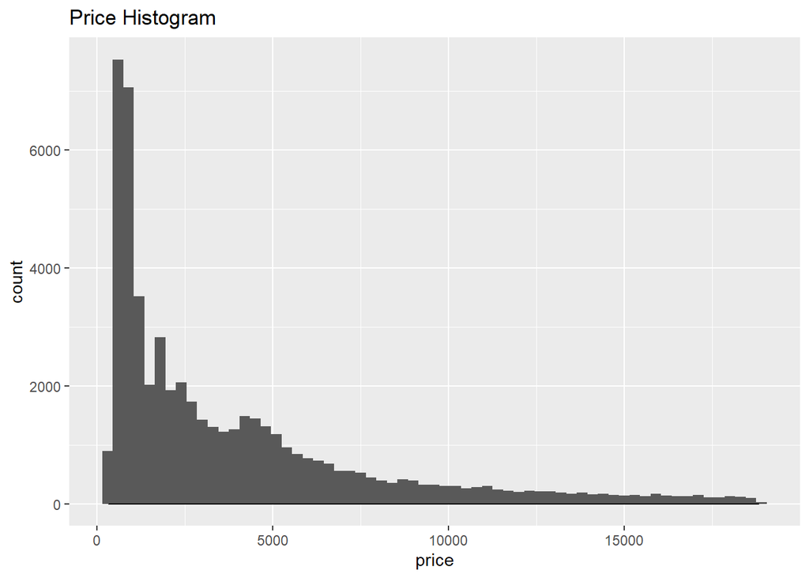

```r
diamonds %>%
  ggplot(aes(x = price))+
  geom_histogram(binwidth = 300)+
  geom_density()+
  labs(title = "Price Histogram")
```

## The Relationships between Price and Variables

In these plots, the linear relationships between price and data’s variables are shown.

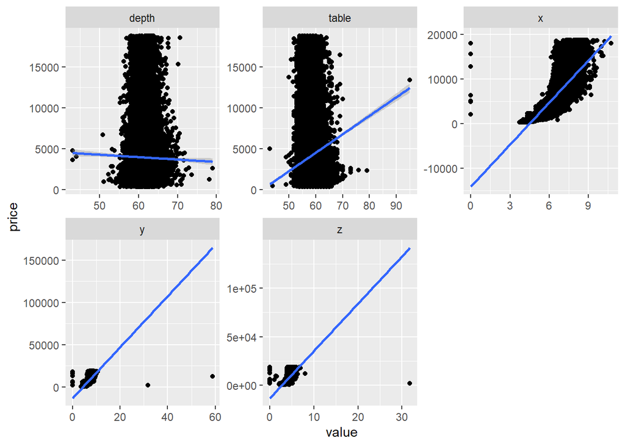

```r
diamonds %>%
  gather(-carat, -cut, -color, -clarity, -price, key = "variance", value = "value") %>%
  ggplot(aes(x = value, y = price))+
  geom_point()+
  geom_smooth(formula= y~x, method='lm')+
  facet_wrap(~variance, scales = "free")
```

## Correlations

This correlation matrix is formed to indicate the strength of the relationship among all numerical variables. According to this matrix, price, carat, x, y, and z variables have significantly positive relationship with each other. On the other hand, depth and table variables have a low negative correlation.

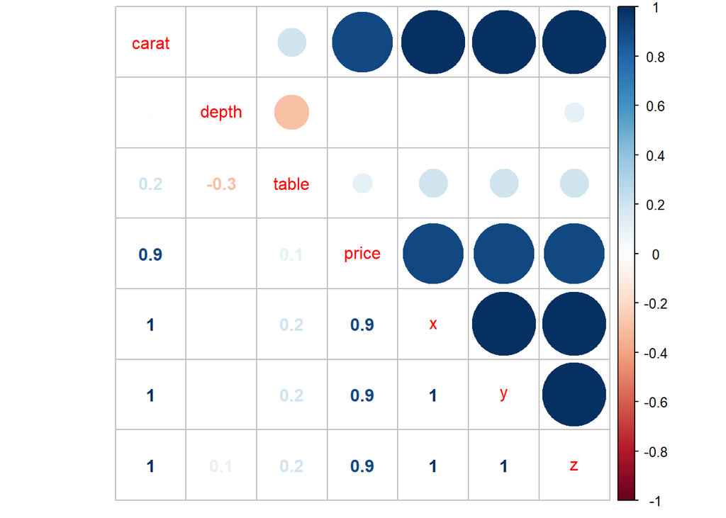

```r
diamonds_numerical <- diamonds %>% select(-cut, -color, -clarity)

diamonds_correlation <- round(cor(diamonds_numerical), 1)

corrplot.mixed(diamonds_correlation)
```

# Creating Models

## Training and Test Data Sets

To form a prediction model for prices of the diamonds, firstly, we should create training and test data sets.

The first table includes a sample from train data set.

```r
set.seed(503)

diamonds_test <- diamonds %>% mutate(diamond_id = row_number()) %>%
    group_by(cut, color, clarity) %>% sample_frac(0.2) %>% ungroup()

diamonds_train <- anti_join(diamonds %>% mutate(diamond_id = row_number()),
    diamonds_test, by = "diamond_id")

diamonds_train = diamonds_train[, c(-ncol(diamonds_train))]
diamonds_test = diamonds_test[, c(-ncol(diamonds_test))]

diamonds_train
```

```
## # A tibble: 43,143 x 10
##    carat cut       color clarity depth table price     x     y     z
##    <dbl> <ord>     <ord> <ord>   <dbl> <dbl> <int> <dbl> <dbl> <dbl>
##  1 0.21  Premium   E     SI1      59.8    61   326  3.89  3.84  2.31
##  2 0.23  Good      E     VS1      56.9    65   327  4.05  4.07  2.31
##  3 0.290 Premium   I     VS2      62.4    58   334  4.2   4.23  2.63
##  4 0.31  Good      J     SI2      63.3    58   335  4.34  4.35  2.75
##  5 0.24  Very Good I     VVS1     62.3    57   336  3.95  3.98  2.47
##  6 0.26  Very Good H     SI1      61.9    55   337  4.07  4.11  2.53
##  7 0.22  Fair      E     VS2      65.1    61   337  3.87  3.78  2.49
##  8 0.23  Very Good H     VS1      59.4    61   338  4     4.05  2.39
##  9 0.3   Good      J     SI1      64      55   339  4.25  4.28  2.73
## 10 0.23  Ideal     J     VS1      62.8    56   340  3.93  3.9   2.46
## # ... with 43,133 more rows
```

And, the second table includes a sample from test data set.

```r
diamonds_test
```

```
## # A tibble: 10,797 x 10
##    carat cut   color clarity depth table price     x     y     z
##    <dbl> <ord> <ord> <ord>   <dbl> <dbl> <int> <dbl> <dbl> <dbl>
##  1 1.7   Fair  D     I1       64.7    56  5617  7.46  7.37  4.8
##  2 0.580 Fair  D     SI2      65.1    58  1156  5.25  5.22  3.41
##  3 1     Fair  D     SI2      65.6    66  3767  6.1   6.01  3.97
##  4 1.05  Fair  D     SI2      65.4    59  3816  6.3   6.24  4.1
##  5 0.7   Fair  D     SI2      64.5    60  2167  5.53  5.47  3.55
##  6 0.9   Fair  D     SI2      64.6    59  3847  6.04  6.01  3.89
##  7 1.01  Fair  D     SI2      64.6    56  3003  6.31  6.24  4.05
##  8 1.1   Fair  D     SI2      64.6    54  4725  6.56  6.49  4.22
##  9 0.62  Fair  D     SI2      64.6    57  1410  5.39  5.33  3.46
## 10 1.5   Fair  D     SI2      68.8    57  7469  6.9   6.86  4.73
## # ... with 10,787 more rows
```

## Multiple Linear Regression

```r
linear_model <- lm(price ~ carat + cut + color + clarity, data = diamonds_train)
summary(linear_model)
```

```
##
## Call:
## lm(formula = price ~ carat + cut + color + clarity, data = diamonds_train)
##
## Residuals:
##      Min       1Q   Median       3Q      Max
## -16801.0   -683.6   -196.5    468.3  10401.1
##
## Coefficients:
##              Estimate Std. Error  t value Pr(>|t|)
## (Intercept) -3723.666     15.628 -238.268  < 2e-16 ***
## carat        8896.038     13.437  662.031  < 2e-16 ***
## cut.L         707.557     22.744   31.109  < 2e-16 ***
## cut.Q        -327.631     20.037  -16.351  < 2e-16 ***
## cut.C         185.351     17.398   10.653  < 2e-16 ***
## cut^4          -4.259     13.928   -0.306    0.760
## color.L     -1905.565     19.821  -96.136  < 2e-16 ***
## color.Q      -627.589     18.028  -34.812  < 2e-16 ***
## color.C      -166.849     16.849   -9.902  < 2e-16 ***
## color^4        11.152     15.472    0.721    0.471
## color^5       -89.472     14.617   -6.121 9.36e-10 ***
## color^6       -59.685     13.287   -4.492 7.08e-06 ***
## clarity.L    4250.715     34.533  123.092  < 2e-16 ***
## clarity.Q   -1858.920     32.277  -57.592  < 2e-16 ***
## clarity.C     936.585     27.624   33.904  < 2e-16 ***
## clarity^4    -379.408     22.085  -17.179  < 2e-16 ***
## clarity^5     223.564     18.013   12.411  < 2e-16 ***
## clarity^6       8.574     15.691    0.546    0.585
## clarity^7     106.284     13.841    7.679 1.64e-14 ***
## ---
## Signif. codes:  0 '***' 0.001 '**' 0.01 '*' 0.05 '.' 0.1 ' ' 1
##
## Residual standard error: 1157 on 43124 degrees of freedom
## Multiple R-squared:  0.9163, Adjusted R-squared:  0.9163
## F-statistic: 2.624e+04 on 18 and 43124 DF,  p-value: < 2.2e-16
```

The first step in interpreting the multiple regression analysis is to examine the F-statistic and the associated p-value, at the bottom of model summary.

For this data, it can be seen that p-value of the F-statistic is < 2.2e-16, which is highly significant. This means that, at least, one of the predictor variables is significantly related to the outcome variable.

To see which predictor variables are significant, we should examine the coefficients table, which shows the estimate of regression beta coefficients and the associated t-statitic p-values:

```r
summary(linear_model)$coefficient
```

```
##                 Estimate Std. Error      t value      Pr(>|t|)
## (Intercept) -3723.666426   15.62805 -238.2681135  0.000000e+00
## carat        8896.038492   13.43750  662.0309226  0.000000e+00
## cut.L         707.557297   22.74414   31.1094336 3.823518e-210
## cut.Q        -327.630879   20.03745  -16.3509277  6.492566e-60
## cut.C         185.350662   17.39823   10.6534216  1.813163e-26
## cut^4          -4.258657   13.92798   -0.3057627  7.597868e-01
## color.L     -1905.564958   19.82149  -96.1363112  0.000000e+00
## color.Q      -627.588885   18.02792  -34.8120587 6.908494e-262
## color.C      -166.848556   16.84928   -9.9024163  4.300797e-23
## color^4        11.151507   15.47225    0.7207423  4.710720e-01
## color^5       -89.471710   14.61659   -6.1212424  9.364710e-10
## color^6       -59.684959   13.28748   -4.4918207  7.079993e-06
## clarity.L    4250.714999   34.53281  123.0920700  0.000000e+00
## clarity.Q   -1858.920401   32.27730  -57.5921826  0.000000e+00
## clarity.C     936.585139   27.62448   33.9041688 1.088004e-248
## clarity^4    -379.408173   22.08498  -17.1794650  6.276524e-66
## clarity^5     223.563716   18.01296   12.4112703  2.608788e-35
## clarity^6       8.573632   15.69120    0.5463975  5.847956e-01
## clarity^7     106.283646   13.84118    7.6787991  1.639645e-14
```

## CART

When we look at the below plot of a tree, we see that carat, clarity, and y variables are used for branching. So, these variables are better to decrease the variance in the data. If we make a cross validation for cp value, we can get a more detailed tree plot.

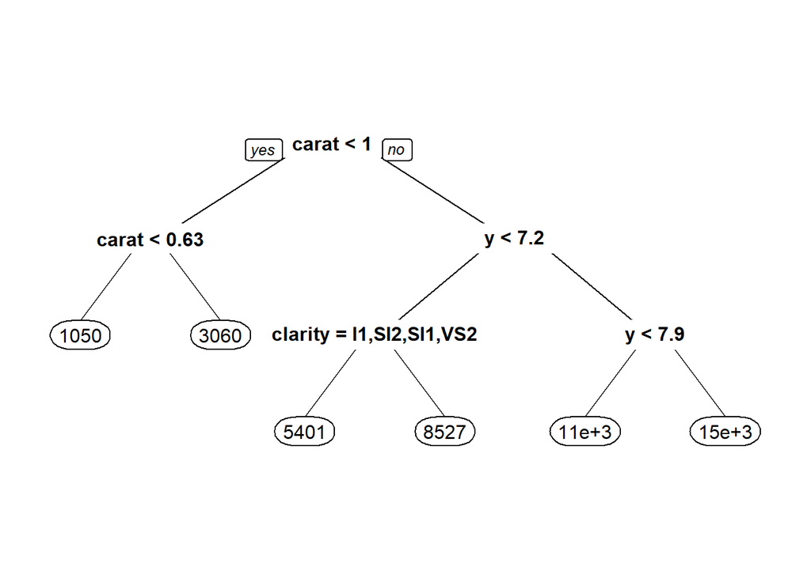

```r
rpart_model <- rpart(price ~ ., data = diamonds_train)

prp(rpart_model)
```

As can be seen in the figure below, using 0.001 value for cp is better than other cp values.

```r
train_control = trainControl(method = "cv", number = 10)

cp_grid = expand.grid( .cp = (1:10)*0.001)

train = train(price~. - carat - cut - color - clarity, data = diamonds_train, method = "rpart", trControl = train_control, tuneGrid = cp_grid)

train
```

```
## CART
##
## 43143 samples
##     9 predictor
##
## No pre-processing
## Resampling: Cross-Validated (10 fold)
## Summary of sample sizes: 38829, 38828, 38830, 38828, 38830, 38828, ...
## Resampling results across tuning parameters:
##
##   cp     RMSE      Rsquared   MAE
##   0.001  1431.514  0.8717525  836.9259
##   0.002  1445.643  0.8692092  842.7864
##   0.003  1446.845  0.8690031  842.8444
##   0.004  1446.845  0.8690031  842.8444
##   0.005  1457.954  0.8669307  876.1275
##   0.006  1486.978  0.8616126  942.5725
##   0.007  1507.705  0.8577574  971.2047
##   0.008  1540.100  0.8515755  988.7643
##   0.009  1548.420  0.8499704  993.0798
##   0.010  1548.420  0.8499704  993.0798
##
## RMSE was used to select the optimal model using the smallest value.
## The final value used for the model was cp = 0.001.
```

The second plot tree is more detail. According to this plot of tree, the price is setting in regard to carat, clarity, y, and color variables. We can compare these two tree plot with their R^2 values.

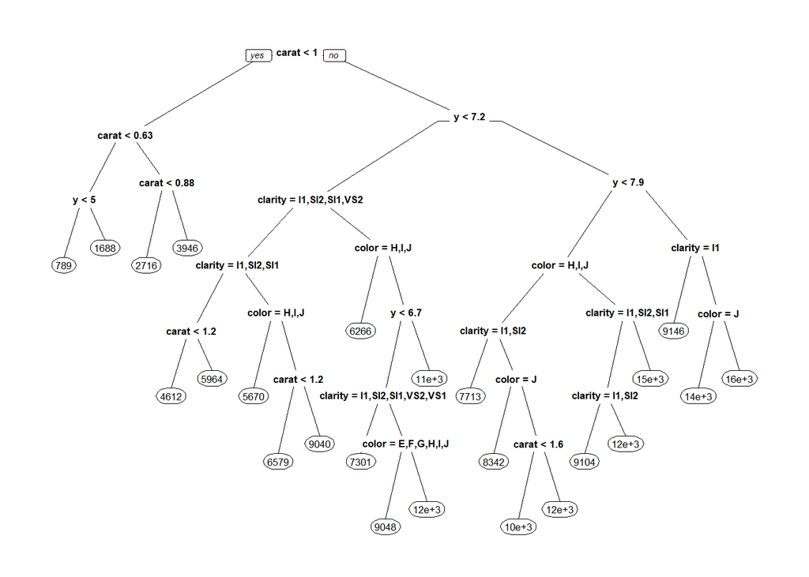

```r
rpart_model2 <- rpart(price ~ ., data = diamonds_train, cp = 0.001)

prp(rpart_model2)
```

According to these below calculations, we can say that the second CART model is better.

```r
rpart_model_prediction <- predict(rpart_model, newdata = diamonds_test)

rpart_model_r2 <- 1 - (sum((rpart_model_prediction - diamonds_test$price) ^ 2 ) / sum((diamonds_test$price - mean(diamonds_train$price)) ^ 2))

rpart_model_r2
```

```
## [1] 0.8785433
```

```r
rpart_model2_prediction <- predict(rpart_model2, newdata = diamonds_test)

rpart_model2_r2 <- 1 - (sum((rpart_model2_prediction - diamonds_test$price) ^ 2 ) / sum((diamonds_test$price - mean(diamonds_train$price)) ^ 2))

rpart_model2_r2
```

```
## [1] 0.9422453
```

# References

[Wikipedia](https://en.wikipedia.org/wiki/Diamond)

[Petragems Diamonds Price Factors](https://www.petragems.com/education/comparing-diamond-prices-seven-important-factors/)

[cran.r-project “corrplot” Package](https://cran.r-project.org/web/packages/corrplot/vignettes/corrplot-intro.html)

[STHDA - Regression Analysis](http://www.sthda.com/english/articles/40-regression-analysis/168-multiple-linear-regression-in-r/)

[STHDA - CART Model](http://www.sthda.com/english/articles/35-statistical-machine-learning-essentials/141-cart-model-decision-tree-essentials/)